# Introdução

Este relatório objetiva apresentar e discutir os resultados obtidos em sessões de experimentos realizadas na Universidade Federal da Bahia. Os experimentos foram todos conduzidos com auxílio de uma placa Arduino Uno, que foi programada para fazer medições de corrente e de tensão em circuitos.

Os dados obtidos foram organizados e tratados utilizando o ambiente de programação “R”. Todas as medidas presentes nos códigos R são dadas no SI (Sistema Internacional de Medidas), a menos que explicitado o contrário. Todas as medidas presentes em gráficos e tabelas estarão acompanhadas da unidade utilizada.

# Experimentos

Primeiramente, como interface comum entre todos os experimentos, montamos a placa Arduino junto a uma protoboard e a um display LCD 2x16.

## Medida de Corrente (aquecimento)

### Esquema

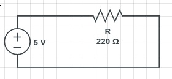

Circuito com R = 220 ohm

### Código utilizado

```cpp
#include <LiquidCrystal.h>
using namespace std;

const int rs = 12, en = 11, d4 = 5, d5 = 4, d6 = 3, d7 = 2;
LiquidCrystal lcd(rs, en, d4, d5, d6, d7);
const float V = 5.0, R = 220.0;

void setup() {
 lcd.begin(16, 2);
}

void loop(){
  lcd.clear();
  lcd.print("A0   A1   Cor");

  float a0 = analogRead(A0) / (1023.0 / 5.0);
  float a1 = analogRead(A1) / (1023.0 / 5.0);
  float amp = abs(a1 - a0) / R;
  lcd.setCursor(0, 1);
  lcd.print(String(a0, 1) + "V");
  lcd.setCursor(5, 1);
  lcd.print(String(a1, 1) + "V");
  lcd.setCursor(10, 1);
  lcd.print(String(amp, 3) + "A");

  delay(100);
}
```

## Medida de corrente e de resistência desconhecida

Em sequência, uma novo resistor com valor de resistência desconhecido ($r$) foi adicionado ao circuito, como mostrado no esquema abaixo. A nova tarefa, então, foi descobrir a resistência desse novo componente, novamente utilizando a lei de Ohm, mas agora com associação de resistores em série: $V = (R+r) i$.

### Esquema

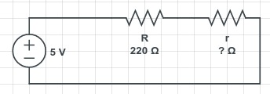

Circuito com R = 220 ohm e r desconhecido

### Código utilizado

```cpp
#include <LiquidCrystal.h>
using namespace std;

const int rs = 12, en = 11, d4 = 5, d5 = 4, d6 = 3, d7 = 2;
LiquidCrystal lcd(rs, en, d4, d5, d6, d7);
const float R = 220.0;

void setup() {
 lcd.begin(16, 2);
}

float roundTo(float x, int places) {
  for(int i = 0; i < places; i++) x *= 10;
  float y = (int)round(x);
  for(int i = 0; i < places; i++) y /= 10;
  return y;
}

String getString(float x, int places = 0) {
  if(places == 0)
    return String((int)roundTo(x, 0));
  return String(roundTo(x, places), places);
}

void loop(){
  lcd.clear();
  lcd.print("Ten   Cor   Res2");

  float a0 = analogRead(A0) / (1023.0 / 5.0);
  float a1 = analogRead(A1) / (1023.0 / 5.0);
  float amp = (a1 - a0) / R;

  float a3 = analogRead(A3) / (1023.0 / 5.0);
  float R2 = (a3 - a1) / amp;

  lcd.setCursor(0, 1);
  lcd.print(getString(a0, 1) + "V");
  lcd.setCursor(5, 1);
  lcd.print(getString(abs(amp * 1000)) + "mA");
  lcd.setCursor(10, 1);
  lcd.print(getString(R2) + "ohm");

  delay(100);
}
```

## Fotos

[figure not shown]

Com fonte eletromotriz do Arduino

[figure not shown]

Com bateria de 1.5 V

## Circuito RC

Num último momento, montamos um circuito RC como o mostrado abaixo e acompanhamos o processo de carga e de descarga do capacitor por cerca de 20 minutos, anotando a diferenção de tensão no sistema a cada 20 segundos a fim de analisar a curva formada.

### Esquema

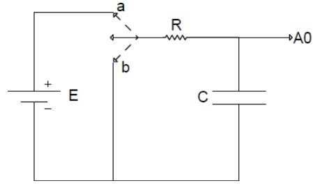

Circuito RC

## Fotos

[figure not shown]

Com fonte eletromotriz do Arduino